# Genes and Geography in Europe

```r
suppressMessages(library(tidyverse))
suppressMessages(library(vegan))
```

```r
suppressMessages(library(maps))
suppressMessages(library(geosphere))
```

The dataset for reproducing the main figures is available from the [Novembre lab Github repository](https://github.com/NovembreLab/Novembre_etal_2008_misc). Here, we will use a minimally reformatted versions of the main PCA results table. There are two expected outcomes of this exercise:

**Recreate the PCA plot in Figure 1 starting from the PCA results table**

To achieve this, you should carry out the following steps:

- Read the [dataset](https://www.dropbox.com/s/skwwqwqtymecsct/novembre_2008_pca.tsv?dl=1) containing PCA coordinate and geographic locations, as well as the [color palette table](https://www.dropbox.com/s/6wu3s2wvmlfu5cz/novembre_2008_colours.tsv?dl=1) into R
- Rotate the original PCA coordinates to maximize the correlation between PCs and geographic locations. This can be achieved using the `procrustes()` function of the `vegan` R package. The function takes two matrix objects as input, the first one the target matrix (i.e. the geographic coordinates), and the second one the matrix to be rotated (i.e. the PCA result). More details on how to use the function can be found in the help page by typing `?procrustes`
- Calculate the optimal rotation angle in degrees from the rotation matrix returned in the `rotation` element of the results object. A rotation matrix defined as

$$\begin{bmatrix}
cos\:\theta & -sin\:\theta \\
sin\:\theta & cos\:\theta
\end{bmatrix}$$

where $\theta$ represents the rotation angle (in unit of radians) counterclockwise from the positive x axis.

- Visualize the resulting rotated PCA using `ggplot2`. Start by trying to replicate the overall PCA plot of samples (using `geom_text()` with the given population labels), with the color scale in the given palette table (using `scale_colour_manual()`). Add population median positions using summary tables produced by `group_by()` and `summarise()`.
- Adding rotated axes and their labels requires a bit more processing. A possible solution would be rotating the coordinates of points at the ends of the original axes into the new coordinates by using the `predict()` function on the procrustes result object, and manually drawing the rotated axes using `geom_segment()`.

**Predict the geographic location of samples from Austria from their PCA position**

To achieve this, you can follow the linear regression approach from Novembre et al:

- Split your data into a test set containing only samples from Austria, and a training set of the remaining individuals.
- Create two linear regression models, one for longitude and one for latitude as outcomes. For each model, use both rotated PC1 and PC2, as well as their interaction as predictors. The syntax for such a model in R is `lm(response ~ predictor1 * predictor2, data = data)`.
- Obtain the predicted longitude and latitude for the test samples using the `predict()` function on both models.
- Evaluate prediction accuracy by calculating the average distance of the predicted locations from the true location. The distance between two points defined by longitude/latitude can be calculated using the “Haversine” great circle distance, implemented in the `distHaversine()` function of the `geosphere` R package.
- Plot the actual and predicted locations of the test samples on a map. You can find a simple example of how to plot spatial data in `ggplot2` towards the end of the chapter “[Data visualization](https://r4ds.had.co.nz/data-visualisation.html)” of the “R for data science” book.

The following sections of this document show an example solution for these tasks

## Preparing the dataset

First we’ll need to read in the PCA results and color map

```r
pca <- read_tsv("https://www.dropbox.com/s/skwwqwqtymecsct/novembre_2008_pca.tsv?dl=1")
colors <- read_tsv("https://www.dropbox.com/s/6wu3s2wvmlfu5cz/novembre_2008_colours.tsv?dl=1",
                   col_names = c("country", "color"))
```

The variable `pca` contains the results of the principal component analysis of 1,387 European individuals from Novembre et al 2008. Let’s have a look at the first few lines of the dataset:

| sampleId | country | alabels | longitude | latitude | PC1 | PC2 |
| --- | --- | --- | --- | --- | --- | --- |
| ind_474 | Croatia | HR | 16.10000 | 45.32000 | 0.0111 | -0.0460 |
| ind_660 | Serbia and Montenegro | YG | 20.61572 | 43.94949 | -0.0300 | -0.0443 |
| ind_1890 | Czech Republic | CZ | 15.37698 | 49.73661 | 0.0137 | -0.0444 |
| ind_1923 | Bosnia and Herzegovina | BA | 17.86202 | 44.17588 | 0.0028 | -0.0493 |
| ind_2083 | Serbia and Montenegro | YG | 20.61572 | 43.94949 | -0.0031 | -0.0416 |
| ind_2733 | Serbia and Montenegro | YG | 20.61572 | 43.94949 | -0.0026 | -0.0424 |

The color palette used for the countries is stored as a table in the variable `colors`:

| country | color |
| --- | --- |
| Germany | gold1 |
| Netherlands | orange |
| Austria | tan3 |
| Luxembourg | yellow |
| Czech Republic | yellowgreen |
| Hungary | gold2 |

## Recreating Figure 1 of Novembre et al 2008

### Rotating the PCA

In order to find the rotation for the PCA that aligns best with the geographic location of the samples, we will use the `procrustes()` function from the package `vegan`. We first need to convert both the principal components and geographic locations of the samples into matrix format.

```r
loc <- pca %>%
    select(longitude, latitude) %>%
    as.matrix()

pca1 <- pca %>%
    select(PC1, PC2) %>%
    as.matrix()
```

Now we carry out the procrustes analysis to find the optimal rotation

```r
rot <- procrustes(loc, pca1)
```

We can examine the result by using base R `plot` function on the resulting object

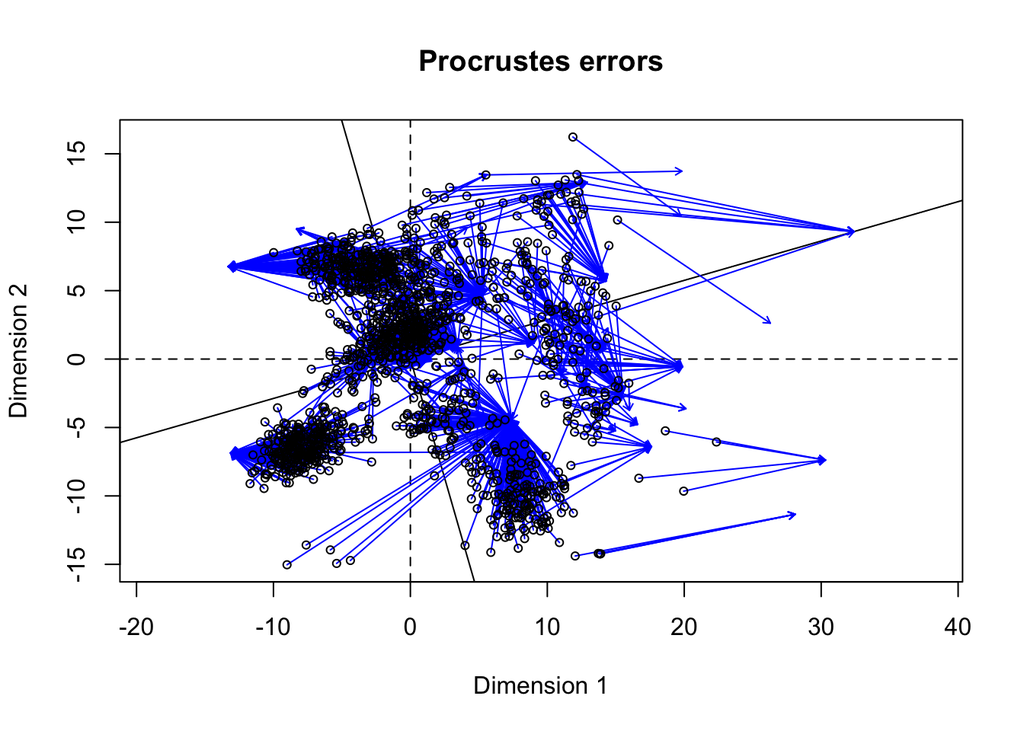

```r
plot(rot)
```

The rotated PC coordinates can be extracted from the `Yrot` element of the result object. Here we add two new columns for the rotated PCs to our `pca` object

```r
pca <- pca %>%
    mutate(PC1_rot = rot$Yrot[,1],
           PC2_rot = rot$Yrot[,2])
```

We can obtain the optimal rotation angle in degrees from the rotation matrix returned in the `rotation` element of the results object. A rotation matrix defined as

$$\begin{bmatrix}
cos\:\theta & -sin\:\theta \\
sin\:\theta & cos\:\theta
\end{bmatrix}$$

will rotate points counterclockwise by the angle $\theta$ (in unit of radians) from the positive x axis. Using the first element of the matrix we can therefore obtain the angle in degrees as

```r
theta1 <- atan2(rot$rotation[2,1], rot$rotation[1,1]) * 180 / pi
```

Our best-fitting rotation angle is -106 degrees.

### Plotting the rotated PCA

With the rotated PCA results calculated, everything is in place for creating the figure. First we set up the color scale for the countries

```r
colorscale <- colors$color
names(colorscale) <- colors$country
```

Next, we calculate the median PC values for each country

```r
pca_summary <- pca %>%
    group_by(country, alabels) %>%
    summarise_at(c("PC1_rot", "PC2_rot"), median)
```

To add rotated axes lines, we take the coordinates of the four points at the end of the axis ranges, and rotate them into the new coordinate space using the `predict` function on the procrustes output object

```r
lim_pc1 <- extendrange(pca$PC1)
lim_pc2 <- extendrange(pca$PC2)

axis <- rbind(c(lim_pc1[1], 0), c(lim_pc1[2], 0), c(0, lim_pc2[1]), c(0, lim_pc2[2]))
axis_rot <- predict(rot, axis, truemean = FALSE)
axis_rot_df  <- tibble(x = axis_rot[c(1, 3),1],
                       xend = axis_rot[c(2, 4),1],
                       y = axis_rot[c(1, 3),2],
                       yend = axis_rot[c(2, 4), 2])
```

Similarly, we calculate rotated coordinates for two axis labels, in a position shifted towards the origin from the axis end point

```r
labels <- rbind(c(lim_pc1[2] * 0.85, 0), c(0, lim_pc2[2] * 0.85))
labels_rot <- predict(rot, labels, truemean = FALSE) %>%
    as_tibble() %>%
    mutate(labels = c("PC1", "PC2"))
colnames(labels_rot)[1:2] <- c("PC1_rot", "PC2_rot")
```

Finally, we can use our previously obtained rotation angle `theta1` of -106 degrees to adjust the angles for the axis label text.

With all objects in place we can now build the final plot

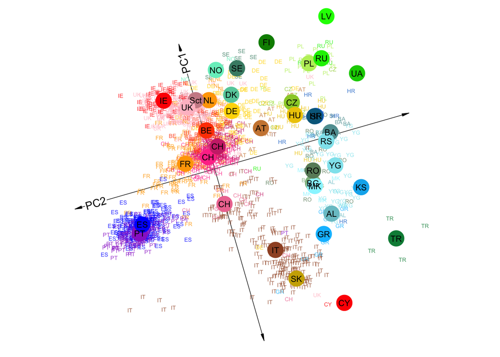

```r
p <- ggplot(pca, aes(x = PC1_rot,
                     y = PC2_rot))
p +
    geom_segment(aes(x = x,
                     xend = xend,
                     y = y,
                     yend = yend),
                 size = 0.25,
                 arrow = arrow(ends = "both",
                               angle = 10,
                               type = "closed",
                               length = unit(0.02, "npc")),
                 data = axis_rot_df) +
    geom_point(size = 10,
               colour = "white",
               data = labels_rot) +
    geom_text(aes(label = labels),
              angle = c(360 - theta1, 270-theta1),
              data = labels_rot) +
    geom_text(aes(label = alabels,
                  colour = country),
              alpha = 0.8,
              size = 2) +
    geom_point(aes(colour = country),
               size = 7,
               data = pca_summary) +
    geom_text(aes(label = alabels),
              size = 3,
              data = pca_summary) +
    scale_color_manual(name = "Country",
                       values = colorscale) +
    coord_equal() +
    theme_void() +
    theme(legend.position = "none")
```

## Predicting location of origin from the PCA position

In the second part of the exercise, we will follow the paper and build a predictor for an individual’s geographic location from its PCA position, using linear regression. As test case, we take all individuals from Austria, remove them from the dataset and use the remaining individuals to build the model. Then, we use the built model to predict the location of the test individuals.

First we split our dataset into training and test data

```r
test_country <- "Austria"
d_train <- pca %>%
  filter(country != test_country)
d_test <- pca %>%
  filter(country == test_country)
```

Next, we carry out two linear regressions, modelling both longitude and latitude as functions of the rotated PCs and including an interaction term

```r
lm_long <- lm(longitude ~ PC1_rot * PC2_rot, data = d_train)
lm_lat <- lm(latitude ~ PC1_rot * PC2_rot, data = d_train)
```

We can examine the fit of the linear models using the `summary()` function

```r
summary(lm_long)
```

```
##
## Call:
## lm(formula = longitude ~ PC1_rot * PC2_rot, data = d_train)
##
## Residuals:
##      Min       1Q   Median       3Q      Max
## -26.6455  -2.8310  -0.0833   2.7034  26.3458
##
## Coefficients:
##                  Estimate Std. Error t value Pr(>|t|)
## (Intercept)      5.077331   0.116389  43.624   <2e-16 ***
## PC1_rot          1.348395   0.019344  69.707   <2e-16 ***
## PC2_rot         -0.031436   0.018474  -1.702   0.0891 .
## PC1_rot:PC2_rot  0.023856   0.002659   8.971   <2e-16 ***
## ---
## Signif. codes:  0 '***' 0.001 '**' 0.01 '*' 0.05 '.' 0.1 ' ' 1
##
## Residual standard error: 4.312 on 1369 degrees of freedom
## Multiple R-squared:  0.7892, Adjusted R-squared:  0.7888
## F-statistic:  1709 on 3 and 1369 DF,  p-value: < 2.2e-16
```

```r
summary(lm_lat)
```

```
##
## Call:
## lm(formula = latitude ~ PC1_rot * PC2_rot, data = d_train)
##
## Residuals:
##     Min      1Q  Median      3Q     Max
## -6.0076 -1.3040 -0.1931  1.1793 13.2889
##
## Coefficients:
##                  Estimate Std. Error t value Pr(>|t|)
## (Intercept)     46.450964   0.054729 848.747   <2e-16 ***
## PC1_rot         -0.077698   0.009096  -8.542   <2e-16 ***
## PC2_rot          0.757596   0.008687  87.209   <2e-16 ***
## PC1_rot:PC2_rot -0.032932   0.001250 -26.336   <2e-16 ***
## ---
## Signif. codes:  0 '***' 0.001 '**' 0.01 '*' 0.05 '.' 0.1 ' ' 1
##
## Residual standard error: 2.028 on 1369 degrees of freedom
## Multiple R-squared:  0.849,  Adjusted R-squared:  0.8487
## F-statistic:  2567 on 3 and 1369 DF,  p-value: < 2.2e-16
```

Both models result in significant fits with the largest estimated effect sizes for the rotated PC1 / PC2 coordinates on longitude / latitude respectively.

Now we use the `predict()` function to infer the predicted geographic location for the test samples, and reshape the results into a format useful for plotting

```r
d1 <- d_test %>%
  select(sampleId, longitude, latitude) %>%
  mutate(longitude_pr = predict(lm_long, d_test),
         latitude_pr = predict(lm_lat, d_test),
         longitude_orig = longitude,
         latitude_orig = latitude)
```

To evaluate the accuracy of the predicted locations, we can calculate the average distance between the predicted and true location for each sample using the “Haversine” great circle distance, implemented in the `distHaversine()` function of the `geosphere` R package.

```r
pred_accuracy <- d1 %>%
  rowwise() %>%
  mutate(dh = distHaversine(c(longitude_pr, latitude_pr), c(longitude, latitude))) %>%
  ungroup() %>%
  summarise(dh_avg_km = mean(dh)/1e3)
```

The average distance of the predicted location for the individuals from Austria is 327 km.

Finally, we can plot the inferred versus actual sample locations using the basic map plotting functionality in `ggplot2`. We reshape the results table into a longer format and plot the predicted and original locations on a map of Europe

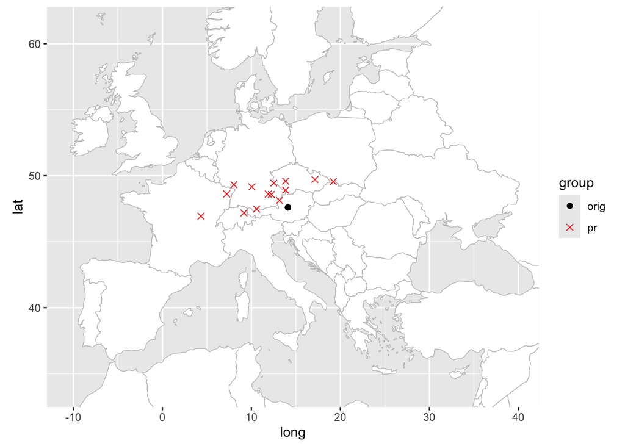

```r
d2 <- d1 %>%
    select(-longitude:-latitude) %>%
    pivot_longer(-sampleId) %>%
    separate(name, into = c("variable", "group")) %>%
    pivot_wider(names_from = variable,
                values_from = value)

w <- map_data("world")

lim_long <- extendrange(pca$longitude)
lim_lat <- extendrange(pca$latitude)

pal <- c("black", "red")
names(pal) <- c("orig", "pr")
sh <- c(16, 4)
names(sh) <- c("orig", "pr")

p <- ggplot(w)
p +
    geom_polygon(aes(long,
                     lat,
                     group = group),
                 fill = "white",
                 color = "grey",
                 size = 0.25) +
    geom_point(aes(x = longitude,
                   y = latitude,
                   colour = group,
                   shape = group),
               size = 2,
               data = d2) +
    scale_color_manual(values = pal) +
    scale_shape_manual(values = sh) +
    coord_quickmap(xlim = lim_long, ylim = lim_lat)
```